# Fraude - copia

Fuente:  
https://www.kaggle.com/datasets/ealaxi/banksim1

BankSim is an agent-based simulator of bank payments based on a sample of aggregated transactional data provided by a bank in Spain. The main purpose of BankSim is the generation of synthetic data that can be used for fraud detection research. Statistical and a Social Network Analysis (SNA) of relations between merchants and customers were used

Paper original de los datos  
https://www.researchgate.net/publication/265736405_BankSim_A_Bank_Payment_Simulation_for_Fraud_Detection_Research

```python
import warnings
import os
warnings.filterwarnings('ignore')

# Para operaciones básicas de manipulación de datos
import numpy as np
import pandas as pd
import pickle

# Para visualización de datos
import matplotlib.pyplot as plt
import seaborn as sns
from pandas import plotting
from pandas.plotting import parallel_coordinates

# para modelación
import joypy
import imblearn # Escrita sobre scikit learn- sirve para trabajar con datos desproporcionados
from imblearn.ensemble import BalancedBaggingClassifier
from imblearn.ensemble import EasyEnsembleClassifier
from imblearn.over_sampling import SMOTE
from imblearn.ensemble import BalancedRandomForestClassifier


from sklearn.linear_model import LogisticRegression
from sklearn.tree import DecisionTreeClassifier
from sklearn.utils import resample

# Fase de modelamiento de datos usando algoritmos de ML
from sklearn.preprocessing import LabelEncoder
from sklearn.preprocessing import StandardScaler
from sklearn.model_selection import train_test_split, GridSearchCV
from sklearn.preprocessing import MinMaxScaler
from sklearn.model_selection import GridSearchCV
from sklearn.preprocessing import OneHotEncoder


from sklearn.metrics import classification_report
from sklearn.metrics import confusion_matrix, accuracy_score, precision_score, recall_score, f1_score
from sklearn.metrics import roc_curve, roc_auc_score, precision_recall_curve, auc

# Para explicación del modelo
import eli5
import pdpbox
import shap
from eli5.sklearn import PermutationImportance
#from pdpbox import pdp, info_plots #for partial plots

# import TPOT # Escrita sobre scikit learn- sirve para realizar pipeline
# import Yellowbrick # Escrita sobre scikit learn- sirve para realizar visualizacion y fixear los alg de ML

# Modelos de ML
from sklearn.ensemble import VotingClassifier
from sklearn.ensemble import RandomForestClassifier
from sklearn.ensemble import RandomForestClassifier
from sklearn.naive_bayes import MultinomialNB
from sklearn.neural_network import MLPClassifier
from sklearn.svm import LinearSVC

from sklearn import svm
from sklearn.neighbors import NearestCentroid
import xgboost as xgb
```

# Cargar data

```python
# Importamos los datos
df1 = pd.read_csv("bsNET140513_032310.csv")
df1["ID"]= df1.index
# hechemos un vistazo a los datos
#pd.set_option('display.max_columns', None)
df1.head(3),df1.shape[0]
```

```
(          Source         Target  Weight            typeTrans  fraud  ID
 0  'C1093826151'   'M348934600'    4.55  'es_transportation'      0   0
 1   'C352968107'   'M348934600'   39.68  'es_transportation'      0   1
 2  'C2054744914'  'M1823072687'   26.89  'es_transportation'      0   2,
 594643)
```

```python
# Importamos los datos
df2 = pd.read_csv("bs140513_032310.csv")
df2["ID"]= df2.index
# hechemos un vistazo a los datos
#pd.set_option('display.max_columns', None)
df2.head(3)
```

|  | step | customer | age | gender | zipcodeOri | merchant | zipMerchant | category | amount | fraud | ID |
| --- | --- | --- | --- | --- | --- | --- | --- | --- | --- | --- | --- |
| 0 | 0 | 'C1093826151' | '4' | 'M' | '28007' | 'M348934600' | '28007' | 'es_transportation' | 4.55 | 0 | 0 |
| 1 | 0 | 'C352968107' | '2' | 'M' | '28007' | 'M348934600' | '28007' | 'es_transportation' | 39.68 | 0 | 1 |
| 2 | 0 | 'C2054744914' | '4' | 'F' | '28007' | 'M1823072687' | '28007' | 'es_transportation' | 26.89 | 0 | 2 |

```python
data = pd.merge(df1, df2, on=list(set(df1.columns) & set(df2.columns)), how='inner')
data = data.drop(['ID',"Source","Target","category","Weight"], axis = 1)
data.head(2)
```

|  | typeTrans | fraud | step | customer | age | gender | zipcodeOri | merchant | zipMerchant | amount |
| --- | --- | --- | --- | --- | --- | --- | --- | --- | --- | --- |
| 0 | 'es_transportation' | 0 | 0 | 'C1093826151' | '4' | 'M' | '28007' | 'M348934600' | '28007' | 4.55 |
| 1 | 'es_transportation' | 0 | 0 | 'C352968107' | '2' | 'M' | '28007' | 'M348934600' | '28007' | 39.68 |

# EDA

## Eliminación de variables constantes

```python
l_var_cte=[]
for col in data.columns:
    print(col, len(data[col].unique()))
    if len(data[col].unique())==1:
        l_var_cte.append(col)

print("Variables constantes:", l_var_cte)
data=data.drop(l_var_cte, axis = 1)

with open("data_clean0.pickle", "wb") as archivo:
    pickle.dump(data, archivo)
```

```
typeTrans 15
fraud 2
step 180
customer 4112
age 8
gender 4
zipcodeOri 1
merchant 50
zipMerchant 1
amount 23767
Variables constantes: ['zipcodeOri', 'zipMerchant']
```

## Eliminación filas con age='U'

La edad no tiene relacion con la cantidad de estafada, pero la probabilidad de ser estafada la persona si.

```python
with open("data_clean0.pickle", "rb") as archivo:
    data = pickle.load(archivo)


print(data[['age','fraud',"amount"]].groupby(['age'], as_index = False).mean().sort_values(by = 'fraud', ascending = False))

print("Cantidad de datos con edad 'U'", data[data['age'] == "'U'"].shape[0], "\ny su porc es:",data[data['age'] == "'U'"].shape[0]/data.shape[0]*100 ,"%")
data=data[data['age'] != "'U'"].reset_index(drop=True)

# Convertir cada elemento del array a entero usando apply y lambda
data['age'] = data['age'].apply(lambda x: x.replace("'", ""))
data['age'] = data['age'].astype(int)
print(data["age"].unique())
data.head(3)
```

```
   age     fraud     amount
0  '0'  0.019576  46.602896
4  '4'  0.012933  38.201522
2  '2'  0.012514  38.358458
3  '3'  0.011928  37.879718
1  '1'  0.011853  37.530909
5  '5'  0.010951  36.426231
6  '6'  0.009748  36.865624
7  'U'  0.005942  36.627623
Cantidad de datos con edad 'U' 1178
y su porc es: 0.19810205451001694 %
[4 2 3 5 1 6 0]
```

|  | typeTrans | fraud | step | customer | age | gender | merchant | amount |
| --- | --- | --- | --- | --- | --- | --- | --- | --- |
| 0 | 'es_transportation' | 0 | 0 | 'C1093826151' | 4 | 'M' | 'M348934600' | 4.55 |
| 1 | 'es_transportation' | 0 | 0 | 'C352968107' | 2 | 'M' | 'M348934600' | 39.68 |
| 2 | 'es_transportation' | 0 | 0 | 'C2054744914' | 4 | 'F' | 'M1823072687' | 26.89 |

```python
#print("Mean feature values per category",data.groupby('typeTrans')['amount','fraud'].mean())
#print("Mean feature values per category",data["typeTrans",'amount','fraud'].groupby('typeTrans').mean())

data[['typeTrans','fraud',"amount"]].groupby(['typeTrans'],
                as_index = False).mean().sort_values(by = 'fraud', ascending = False)

with open("data_clean1.pickle", "wb") as archivo:
    pickle.dump(data, archivo)
```

## Formulación de medida para variables tipo categoricas.

Si consideramos una clase categorica como por ejemplo el tipo de medio de pago, entonces si hacemos un groupby sobre esta columna agruparemos los datos en función de los valores de esta categoría. Lo interesante se produce cuando calculamos el ciertos promedios de cada grupo de valores de esta categoría:

- Fraude: Si aplicamos el promedio, obtenedremos una aproximación de la probabilidad de fraude de cada grupo.
- Amount o cantidad: Si aplicamos el promedio, obtenedremos una aproximación de los montos promedios de cada grupo.

Ahora si multiplicamos $\text{ prob(Fraude)} \times \text{monto}$ entones obtendremos la cantidad promedio de robo por transacción. Esto es debido a que $$ \frac{\text{cant de fraudes}}{\text{total de transacciones}} \times \text{total monto}= \frac{\text{total monto}}{\text{total de transacciones}} \times \text{cant de fraudes} $$

$$ \frac{\text{cant de fraudes}}{\text{total de transacciones}} \times \text{total monto}= \text{monto promedio de cada transacción} \times \text{cant de fraudes} $$

```python
def transf_var_object(data,categories,target):
    for i in range(len(list(categories))):

        col=categories[i]
        print(col)
        if "customer"==col:
            continue
        df=data[[col,target]].groupby([col], as_index = False).mean().sort_values(by = target, ascending = False)

        dom,rec= df[col].tolist(),df[target].tolist()
        data[col+"_"+target] = data[col].replace(dom,rec)
        #break

    return data

with open("data_clean1.pickle", "rb") as archivo:
    data = pickle.load(archivo)

# Creamos una lista de las variables categoricas
data_categorial = data.select_dtypes(include=["object"])

categories = list(data_categorial.columns)
target="fraud"
data=transf_var_object(data,categories,target)
###   --------------

target="amount"
data=transf_var_object(data,categories,target)
###   --------------

target1="fraud"
target2="amount"
for i in range(len(list(categories))):
    col=categories[i]
    print(col)
    if "customer"==col:
        continue
    data[col+"_"+target1+"_"+target2]=data[col+"_"+target1]*data[col+"_"+target2]
###   --------------

data=data.drop(categories, axis = 1)
###   --------------

with open("data_clean2.pickle", "wb") as archivo:
    pickle.dump(data, archivo)
```

```
typeTrans
customer
gender
merchant
typeTrans
customer
gender
merchant
typeTrans
customer
gender
merchant
```

## Correlación de los datos

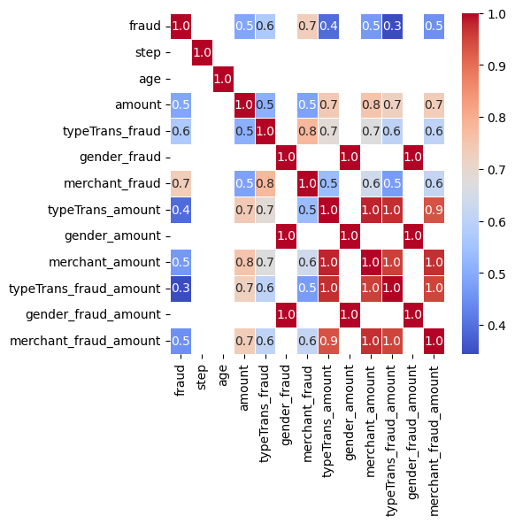

```python
with open("data_clean2.pickle", "rb") as archivo:
    data = pickle.load(archivo)

columnas_numericas=data.select_dtypes(exclude=["object"]).columns

umbral = 0.05
corre=data[columnas_numericas].corr()   # EL -log(x) se tiende al inf cuando x tiende a cero, entonces mientras más alto -log(x) se tiene una corre más baja
abs_corre=np.abs(corre)

boolean_matrix =np.where(abs_corre > umbral, True, False)   # si cumple la condicion la coord tiene una corre alta
sns.heatmap(corre,cmap='coolwarm',linewidths=.5,fmt=".1f",annot = True, mask=~boolean_matrix)
#sns.heatmap(corre,cmap='coolwarm',linewidths=.5,fmt=".1f",annot = True)
```

[output not shown]

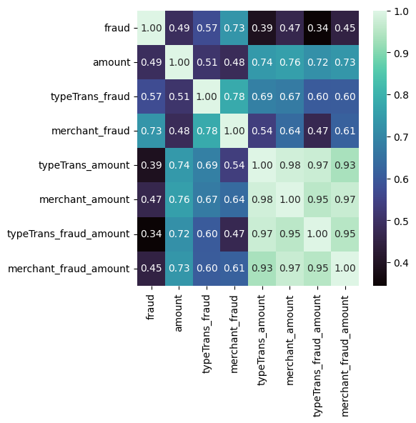

```python
with open("data_clean2.pickle", "rb") as archivo:
    data = pickle.load(archivo)

umbral = 0.1

target="fraud"
num_col_target = data.columns.get_loc(target)
# ------------- # -------------# -------------# -------------

data_correl=data
corr_matrix= abs(data_correl.corr())
boolean_matrix = np.where(corr_matrix>umbral, True,False)

print("Columnas que eliminamos:")
for col,aff in zip(list(data_correl.columns),list(boolean_matrix[num_col_target,:])):
    if aff==False:
        print("-",col)
        data_correl = data_correl.drop(col, axis = 1)

corr_matrix= abs(data_correl.corr())
boolean_matrix = np.where(corr_matrix > umbral,True, False)

fig = plt.figure()
sns.heatmap(corr_matrix, cmap='mako',fmt=".2f",annot = True, mask=~boolean_matrix)
plt.show()

with open("data_clean2.1.pickle", "wb") as archivo:
    pickle.dump(data, archivo)
```

# Modelos de ML

```python
def performance_measure(y_test,y_pred):
    # making a classification report
    cr = classification_report(y_test,  y_pred)
    print(cr)

    # making a confusion matrix
    plt.rcParams['figure.figsize'] = (5, 5)
    cm = confusion_matrix(y_test, y_pred, normalize='true')
    #cm = confusion_matrix(y_test, y_pred)
    sns.heatmap(cm, annot = True, fmt=".2f", cmap="OrRd")

    plt.show()

def escaled_min_max(data,columna):
    XX = data.drop([columna], axis = 1)
    y = data[columna]

    dato_dummies=pd.get_dummies(XX)
    scaler = MinMaxScaler(feature_range=(0, 1)).fit_transform(dato_dummies)

    X = pd.DataFrame(scaler, columns=dato_dummies.columns)
    # 0.5 FUNCION BIEN
    # 0.75 FUNCIONA BIEN
    X_train , X_test , Y_train , Y_test = train_test_split(X,y,test_size= 0.90 ,shuffle=True , random_state=1)

    y_one_hot_train = pd.get_dummies(Y_train).astype(int)
    y_one_hot_test = pd.get_dummies(Y_test).astype(int)

    return X_train , X_test , Y_train , Y_test, y_one_hot_train, y_one_hot_test


def without_escaled(data,columna):
    XX = data.drop([columna], axis = 1)
    y = data[columna]

    dato_dummies=pd.get_dummies(XX).astype(float)

    X_train , X_test , Y_train , Y_test = train_test_split(dato_dummies,y,test_size= 0.2 ,shuffle=True , random_state=1)

    y_one_hot_train = pd.get_dummies(Y_train).astype(int)
    y_one_hot_test = pd.get_dummies(Y_test).astype(int)

    return X_train , X_test , Y_train , Y_test, y_one_hot_train, y_one_hot_test
```

## without techniques sampling

```
Random Forest Classifier:
              precision    recall  f1-score   support

           0       1.00      1.00      1.00    527636
           1       0.86      0.76      0.81      6483

    accuracy                           1.00    534119
   macro avg       0.93      0.88      0.90    534119
weighted avg       1.00      1.00      1.00    534119
```

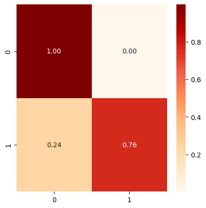

```
Random Forest Classifier class_weight:
              precision    recall  f1-score   support

           0       1.00      1.00      1.00    527636
           1       0.87      0.73      0.79      6483

    accuracy                           1.00    534119
   macro avg       0.93      0.86      0.90    534119
weighted avg       1.00      1.00      1.00    534119
```

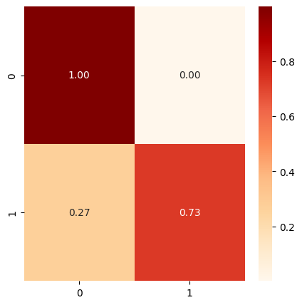

```
Linear SVC:
              precision    recall  f1-score   support

           0       1.00      0.98      0.99    527636
           1       0.39      0.94      0.55      6483

    accuracy                           0.98    534119
   macro avg       0.69      0.96      0.77    534119
weighted avg       0.99      0.98      0.99    534119
```

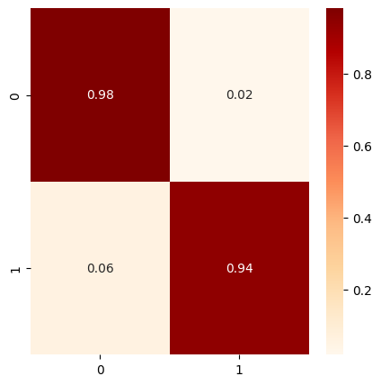

```
Balanced Random Forest Classifier:
              precision    recall  f1-score   support

           0       1.00      0.96      0.98    527636
           1       0.25      0.99      0.40      6483

    accuracy                           0.96    534119
   macro avg       0.63      0.98      0.69    534119
weighted avg       0.99      0.96      0.97    534119
```

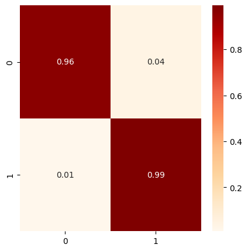

```
Easy Ensemble Classifier:
              precision    recall  f1-score   support

           0       1.00      0.96      0.98    527636
           1       0.24      0.99      0.39      6483

    accuracy                           0.96    534119
   macro avg       0.62      0.98      0.68    534119
weighted avg       0.99      0.96      0.97    534119
```

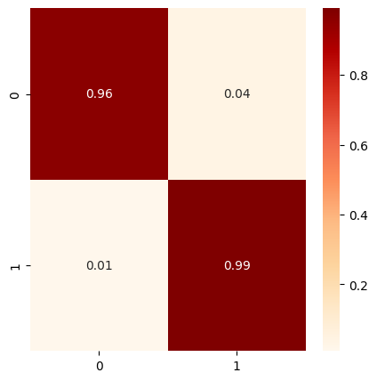

```
Random Forest with Bagging Classifier:
              precision    recall  f1-score   support

           0       1.00      0.97      0.98    527636
           1       0.27      0.99      0.42      6483

    accuracy                           0.97    534119
   macro avg       0.63      0.98      0.70    534119
weighted avg       0.99      0.97      0.98    534119
```

```
Modelo de ML basado en predicciones ponderadas de los 3 modelos anteriores:
              precision    recall  f1-score   support

           0       1.00      0.99      0.99    527636
           1       0.46      0.94      0.62      6483

    accuracy                           0.99    534119
   macro avg       0.73      0.96      0.80    534119
weighted avg       0.99      0.99      0.99    534119
```

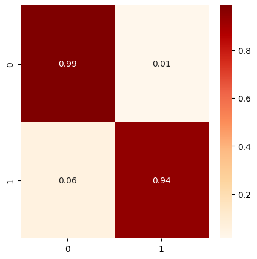

```
VotingClassifier:
              precision    recall  f1-score   support

           0       1.00      0.96      0.98    527636
           1       0.26      0.99      0.41      6483

    accuracy                           0.97    534119
   macro avg       0.63      0.98      0.70    534119
weighted avg       0.99      0.97      0.98    534119
```

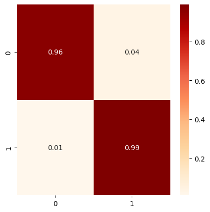

```python
with open("data_clean2.1.pickle", "rb") as archivo:
    data = pickle.load(archivo)

target="fraud"
X_train , X_test , y_train , y_test, y_one_hot_train, y_one_hot_test=escaled_min_max(data,target)
# X_train , X_test , y_train , y_test, y_one_hot_train, y_one_hot_test=without_escaled(data,target)

# Random Forest Classifier
print("Random Forest Classifier:")
model_rf = RandomForestClassifier(random_state=20).fit(X_train, y_train)
y_pred_rf = model_rf.predict(X_test)
performance_measure(y_test, y_pred_rf)

print("Random Forest Classifier class_weight:")
model_rf = RandomForestClassifier(random_state=20,class_weight="balanced").fit(X_train, y_train)
y_pred_rf = model_rf.predict(X_test)
performance_measure(y_test, y_pred_rf)

print("Linear SVC:")
model_rf = LinearSVC(random_state=0, tol=1e-5,class_weight="balanced").fit(X_train, y_train)
y_pred_rf = model_rf.predict(X_test)
performance_measure(y_test, y_pred_rf)

# BalancedRandomForestClassifier
print("Balanced Random Forest Classifier:")
model_brf = BalancedRandomForestClassifier(n_estimators=100, random_state=0).fit(X_train, y_train)
y_pred_brf = model_brf.predict(X_test)
performance_measure(y_test, y_pred_brf)

# Easy Ensemble Classifier
print("Easy Ensemble Classifier:")
model_eec = EasyEnsembleClassifier(n_estimators=5, random_state=0).fit(X_train, y_train)
y_pred_eec = model_eec.predict(X_test)
performance_measure(y_test, y_pred_eec)

# Random Forest with Bagging Classifier
print("Random Forest with Bagging Classifier:")
model_rfbc = BalancedBaggingClassifier(estimator=RandomForestClassifier(),
                                       sampling_strategy='auto',
                                       replacement=False,
                                       random_state=0).fit(X_train, y_train)
y_pred_rfbc = model_rfbc.predict(X_test)
performance_measure(y_test, y_pred_rfbc)

# Modelo de ML basado en predicciones ponderadas de los 3 modelos anteriores
print("Modelo de ML basado en predicciones ponderadas de los 3 modelos anteriores:")
y_pred = y_pred_rf * 0.5 + y_pred_brf * 0.2 + y_pred_eec * 0.3
y_pred = (y_pred > 0.5).astype(int)
performance_measure(y_test, y_pred)

# VotingClassifier
print("VotingClassifier:")
vote_est = [
    ('brf', BalancedRandomForestClassifier(random_state=0)),
    ('bbc', BalancedBaggingClassifier(estimator=RandomForestClassifier(), random_state=0)),
    ('eec', EasyEnsembleClassifier(random_state=0))
]

model_vc = VotingClassifier(estimators=vote_est, voting='soft').fit(X_train, y_train)
y_pred_vc = model_vc.predict(X_test).astype(int)
performance_measure(y_test, y_pred_vc)
```

## With Sampling Techniques:

### *a) Under Sampling*

```python
def under_sampling(data,target):
    # Calcullar index de valores Fraudes y No Fraudes
    # Fraude
    index_frauds = np.array(data[data[target] == 1].index)
    num_frauds = len(index_frauds)
    print("Num fraude:",num_frauds)

    # No Fraude
    index_No_frauds  = np.array(data[data[target] == 0].index)
    num_No_frauds = len(index_No_frauds)
    print("Num No fraude:",num_No_frauds)

    # Crear muestra de index de fraude igual al tamaño del caso de No fraude
    index_No_frauds = np.random.choice(index_No_frauds, size = num_frauds, replace = True)
    index_No_frauds = np.array(index_No_frauds)

    under_sample_index = np.concatenate([index_frauds, index_No_frauds]) # Juntamos los indices de los fraudes y No Fraudes
    undersample_data = data.iloc[under_sample_index, :]  # creating the undersample data
    return undersample_data
```

```
Num fraude: 7193
Num No fraude: 586272
Random Forest Classifier:
              precision    recall  f1-score   support

           0       0.99      0.97      0.98      6449
           1       0.97      0.99      0.98      6499

    accuracy                           0.98     12948
   macro avg       0.98      0.98      0.98     12948
weighted avg       0.98      0.98      0.98     12948
```

```
Random Forest Classifier class_weight:
              precision    recall  f1-score   support

           0       0.99      0.97      0.98      6449
           1       0.97      0.99      0.98      6499

    accuracy                           0.98     12948
   macro avg       0.98      0.98      0.98     12948
weighted avg       0.98      0.98      0.98     12948
```

```
Linear SVC:
              precision    recall  f1-score   support

           0       0.90      0.99      0.94      6449
           1       0.99      0.89      0.94      6499

    accuracy                           0.94     12948
   macro avg       0.94      0.94      0.94     12948
weighted avg       0.94      0.94      0.94     12948
```

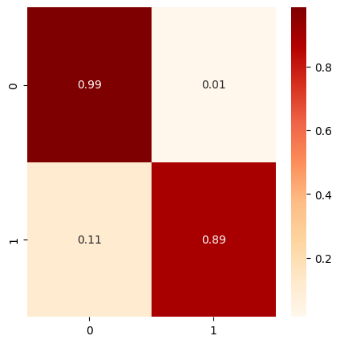

```
Balanced Random Forest Classifier:
              precision    recall  f1-score   support

           0       0.99      0.97      0.98      6449
           1       0.97      0.99      0.98      6499

    accuracy                           0.98     12948
   macro avg       0.98      0.98      0.98     12948
weighted avg       0.98      0.98      0.98     12948
```

```
Easy Ensemble Classifier:
              precision    recall  f1-score   support

           0       0.98      0.97      0.98      6449
           1       0.97      0.98      0.98      6499

    accuracy                           0.98     12948
   macro avg       0.98      0.98      0.98     12948
weighted avg       0.98      0.98      0.98     12948
```

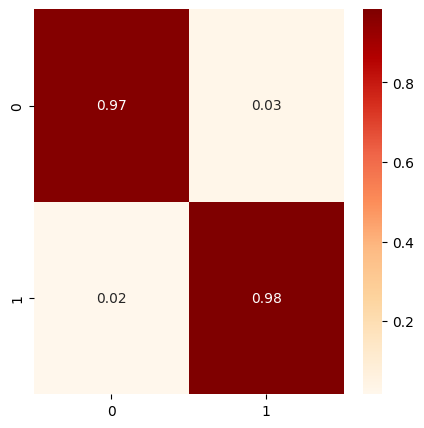

```
Random Forest with Bagging Classifier:
              precision    recall  f1-score   support

           0       0.99      0.97      0.98      6449
           1       0.97      0.99      0.98      6499

    accuracy                           0.98     12948
   macro avg       0.98      0.98      0.98     12948
weighted avg       0.98      0.98      0.98     12948
```

```
Modelo de ML basado en predicciones ponderadas de los 3 modelos anteriores:
              precision    recall  f1-score   support

           0       0.90      0.99      0.94      6449
           1       0.99      0.89      0.94      6499

    accuracy                           0.94     12948
   macro avg       0.94      0.94      0.94     12948
weighted avg       0.94      0.94      0.94     12948
```

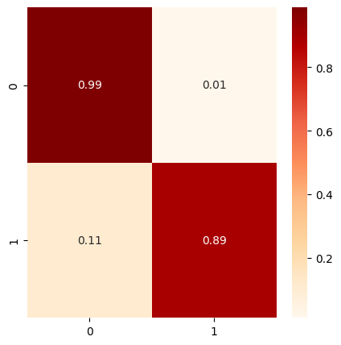

```
VotingClassifier:
              precision    recall  f1-score   support

           0       0.99      0.97      0.98      6449
           1       0.97      0.99      0.98      6499

    accuracy                           0.98     12948
   macro avg       0.98      0.98      0.98     12948
weighted avg       0.98      0.98      0.98     12948
```

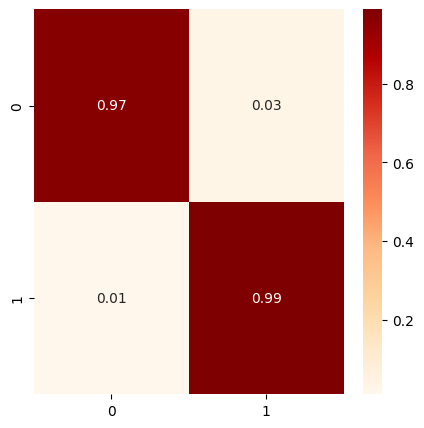

```python
with open("data_clean2.pickle", "rb") as archivo:
    data = pickle.load(archivo)

target="fraud"
data1=under_sampling(data,target)
X_train , X_test , y_train , y_test, y_one_hot_train, y_one_hot_test=escaled_min_max(data1,target)
# X_train , X_test , y_train , y_test, y_one_hot_train, y_one_hot_test=without_escaled(data,target)

# Random Forest Classifier
print("Random Forest Classifier:")
model_rf = RandomForestClassifier(random_state=20).fit(X_train, y_train)
y_pred_rf = model_rf.predict(X_test)
performance_measure(y_test, y_pred_rf)

print("Random Forest Classifier class_weight:")
model_rf = RandomForestClassifier(random_state=20,class_weight="balanced").fit(X_train, y_train)
y_pred_rf = model_rf.predict(X_test)
performance_measure(y_test, y_pred_rf)

print("Linear SVC:")
model_rf = LinearSVC(random_state=0, tol=1e-5,class_weight="balanced").fit(X_train, y_train)
y_pred_rf = model_rf.predict(X_test)
performance_measure(y_test, y_pred_rf)

# BalancedRandomForestClassifier
print("Balanced Random Forest Classifier:")
model_brf = BalancedRandomForestClassifier(n_estimators=100, random_state=0).fit(X_train, y_train)
y_pred_brf = model_brf.predict(X_test)
performance_measure(y_test, y_pred_brf)

# Easy Ensemble Classifier
print("Easy Ensemble Classifier:")
model_eec = EasyEnsembleClassifier(n_estimators=5, random_state=0).fit(X_train, y_train)
y_pred_eec = model_eec.predict(X_test)
performance_measure(y_test, y_pred_eec)

# Random Forest with Bagging Classifier
print("Random Forest with Bagging Classifier:")
model_rfbc = BalancedBaggingClassifier(estimator=RandomForestClassifier(),
                                       sampling_strategy='auto',
                                       replacement=False,
                                       random_state=0).fit(X_train, y_train)
y_pred_rfbc = model_rfbc.predict(X_test)
performance_measure(y_test, y_pred_rfbc)

# Modelo de ML basado en predicciones ponderadas de los 3 modelos anteriores
print("Modelo de ML basado en predicciones ponderadas de los 3 modelos anteriores:")
y_pred = y_pred_rf * 0.5 + y_pred_brf * 0.2 + y_pred_eec * 0.3
y_pred = (y_pred > 0.5).astype(int)
performance_measure(y_test, y_pred)

# VotingClassifier
print("VotingClassifier:")
vote_est = [
    ('brf', BalancedRandomForestClassifier(random_state=0)),
    ('bbc', BalancedBaggingClassifier(estimator=RandomForestClassifier(), random_state=0)),
    ('eec', EasyEnsembleClassifier(random_state=0))
]

model_vc = VotingClassifier(estimators=vote_est, voting='soft').fit(X_train, y_train)
y_pred_vc = model_vc.predict(X_test).astype(int)
performance_measure(y_test, y_pred_vc)
```

### *b) Over Sampling with sample with reemplament*

```python
def over_sampling(data,target):
    # Calcullar index de valores Fraudes y No Fraudes
    # Fraude
    index_frauds = np.array(data[data[target] == 1].index)
    num_frauds = len(index_frauds)
    print("Num fraude:",num_frauds)

    # No Fraude
    index_No_frauds  = np.array(data[data[target] == 0].index)
    num_No_frauds = len(index_No_frauds)
    print("Num No fraude:",num_No_frauds)

    # Crear muestra de index de fraude igual al tamaño del caso de No fraude
    index_frauds = np.random.choice(index_frauds, size = num_No_frauds, replace = True)
    index_frauds = np.array(index_frauds)

    under_sample_index = np.concatenate([index_frauds, index_No_frauds]) # Juntamos los indices de los fraudes y No Fraudes
    undersample_data = data.iloc[under_sample_index, :]  # creating the undersample data
    return undersample_data
```

```
Num fraude: 7193
Num No fraude: 586272
Random Forest Classifier:
              precision    recall  f1-score   support

           0       1.00      0.99      0.99    527540
           1       0.99      1.00      0.99    527750

    accuracy                           0.99   1055290
   macro avg       0.99      0.99      0.99   1055290
weighted avg       0.99      0.99      0.99   1055290
```

```
Random Forest Classifier class_weight:
              precision    recall  f1-score   support

           0       1.00      0.99      0.99    527540
           1       0.99      1.00      0.99    527750

    accuracy                           0.99   1055290
   macro avg       0.99      0.99      0.99   1055290
weighted avg       0.99      0.99      0.99   1055290
```

```
Linear SVC:
              precision    recall  f1-score   support

           0       0.94      0.98      0.96    527540
           1       0.98      0.94      0.96    527750

    accuracy                           0.96   1055290
   macro avg       0.96      0.96      0.96   1055290
weighted avg       0.96      0.96      0.96   1055290
```

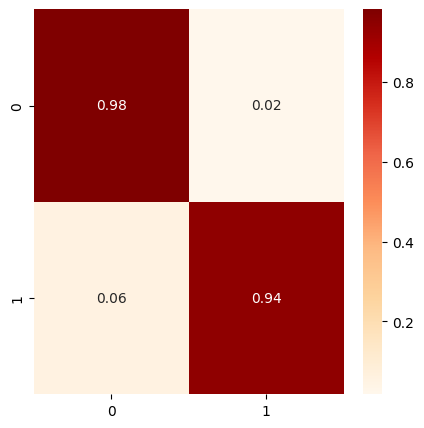

```
Balanced Random Forest Classifier:
              precision    recall  f1-score   support

           0       1.00      0.99      0.99    527540
           1       0.99      1.00      0.99    527750

    accuracy                           0.99   1055290
   macro avg       0.99      0.99      0.99   1055290
weighted avg       0.99      0.99      0.99   1055290
```

```
Easy Ensemble Classifier:
              precision    recall  f1-score   support

           0       0.99      0.97      0.98    527540
           1       0.97      0.99      0.98    527750

    accuracy                           0.98   1055290
   macro avg       0.98      0.98      0.98   1055290
weighted avg       0.98      0.98      0.98   1055290
```

```
Random Forest with Bagging Classifier:
              precision    recall  f1-score   support

           0       1.00      0.98      0.99    527540
           1       0.99      1.00      0.99    527750

    accuracy                           0.99   1055290
   macro avg       0.99      0.99      0.99   1055290
weighted avg       0.99      0.99      0.99   1055290
```

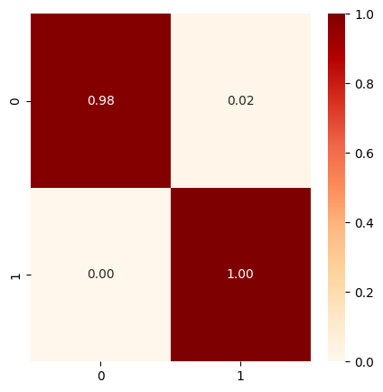

```
Modelo de ML basado en predicciones ponderadas de los 3 modelos anteriores:
              precision    recall  f1-score   support

           0       0.94      0.99      0.97    527540
           1       0.99      0.94      0.96    527750

    accuracy                           0.96   1055290
   macro avg       0.97      0.96      0.96   1055290
weighted avg       0.97      0.96      0.96   1055290
```

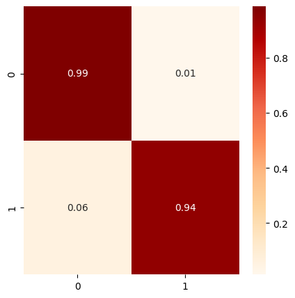

```
VotingClassifier:
              precision    recall  f1-score   support

           0       1.00      0.99      0.99    527540
           1       0.99      1.00      0.99    527750

    accuracy                           0.99   1055290
   macro avg       0.99      0.99      0.99   1055290
weighted avg       0.99      0.99      0.99   1055290
```

```python
with open("data_clean2.pickle", "rb") as archivo:
    data = pickle.load(archivo)

target="fraud"
data=over_sampling(data,target)
X_train , X_test , y_train , y_test, y_one_hot_train, y_one_hot_test=escaled_min_max(data,target)
# X_train , X_test , y_train , y_test, y_one_hot_train, y_one_hot_test=without_escaled(data,target)

# Random Forest Classifier
print("Random Forest Classifier:")
model_rf = RandomForestClassifier(random_state=20).fit(X_train, y_train)
y_pred_rf = model_rf.predict(X_test)
performance_measure(y_test, y_pred_rf)

print("Random Forest Classifier class_weight:")
model_rf = RandomForestClassifier(random_state=20,class_weight="balanced").fit(X_train, y_train)
y_pred_rf = model_rf.predict(X_test)
performance_measure(y_test, y_pred_rf)

print("Linear SVC:")
model_rf = LinearSVC(random_state=0, tol=1e-5,class_weight="balanced").fit(X_train, y_train)
y_pred_rf = model_rf.predict(X_test)
performance_measure(y_test, y_pred_rf)

# BalancedRandomForestClassifier
print("Balanced Random Forest Classifier:")
model_brf = BalancedRandomForestClassifier(n_estimators=100, random_state=0).fit(X_train, y_train)
y_pred_brf = model_brf.predict(X_test)
performance_measure(y_test, y_pred_brf)

# Easy Ensemble Classifier
print("Easy Ensemble Classifier:")
model_eec = EasyEnsembleClassifier(n_estimators=5, random_state=0).fit(X_train, y_train)
y_pred_eec = model_eec.predict(X_test)
performance_measure(y_test, y_pred_eec)

# Random Forest with Bagging Classifier
print("Random Forest with Bagging Classifier:")
model_rfbc = BalancedBaggingClassifier(estimator=RandomForestClassifier(),
                                       sampling_strategy='auto',
                                       replacement=False,
                                       random_state=0).fit(X_train, y_train)
y_pred_rfbc = model_rfbc.predict(X_test)
performance_measure(y_test, y_pred_rfbc)

# Modelo de ML basado en predicciones ponderadas de los 3 modelos anteriores
print("Modelo de ML basado en predicciones ponderadas de los 3 modelos anteriores:")
y_pred = y_pred_rf * 0.5 + y_pred_brf * 0.2 + y_pred_eec * 0.3
y_pred = (y_pred > 0.5).astype(int)
performance_measure(y_test, y_pred)

# VotingClassifier
print("VotingClassifier:")
vote_est = [
    ('brf', BalancedRandomForestClassifier(random_state=0)),
    ('bbc', BalancedBaggingClassifier(estimator=RandomForestClassifier(), random_state=0)),
    ('eec', EasyEnsembleClassifier(random_state=0))
]

model_vc = VotingClassifier(estimators=vote_est, voting='soft').fit(X_train, y_train)
y_pred_vc = model_vc.predict(X_test).astype(int)
performance_measure(y_test, y_pred_vc)
```

### *c) Over Sampling with SMOTE*

```python
def smote_sample(data,target):
    # let's split the data into dependent and independent sets
    X = data.drop(target, axis = 1)
    y = data[target]

    sm = SMOTE(k_neighbors=10,random_state=42)
    X_res, y_res = sm.fit_resample(X, y)
    #print('Resampled dataset shape %s' % Counter(y_res))

    X_res[target]=y_res
    return X_res
```

```
Random Forest Classifier:
              precision    recall  f1-score   support

           0       1.00      0.99      0.99    527751
           1       0.99      1.00      0.99    527539

    accuracy                           0.99   1055290
   macro avg       0.99      0.99      0.99   1055290
weighted avg       0.99      0.99      0.99   1055290
```

```
Random Forest Classifier class_weight:
              precision    recall  f1-score   support

           0       1.00      0.99      0.99    527751
           1       0.99      1.00      0.99    527539

    accuracy                           0.99   1055290
   macro avg       0.99      0.99      0.99   1055290
weighted avg       0.99      0.99      0.99   1055290
```

```
Linear SVC:
              precision    recall  f1-score   support

           0       0.95      0.98      0.96    527751
           1       0.98      0.94      0.96    527539

    accuracy                           0.96   1055290
   macro avg       0.96      0.96      0.96   1055290
weighted avg       0.96      0.96      0.96   1055290
```

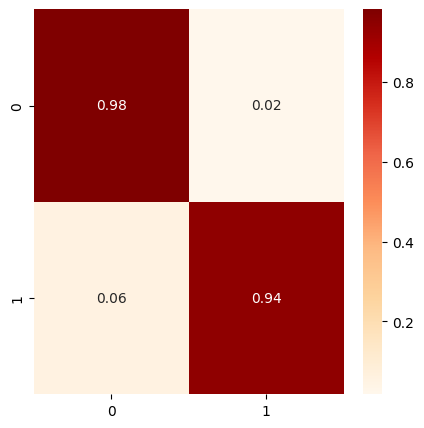

```
Balanced Random Forest Classifier:
              precision    recall  f1-score   support

           0       1.00      0.99      0.99    527751
           1       0.99      1.00      0.99    527539

    accuracy                           0.99   1055290
   macro avg       0.99      0.99      0.99   1055290
weighted avg       0.99      0.99      0.99   1055290
```

```
Easy Ensemble Classifier:
              precision    recall  f1-score   support

           0       1.00      0.96      0.98    527751
           1       0.97      1.00      0.98    527539

    accuracy                           0.98   1055290
   macro avg       0.98      0.98      0.98   1055290
weighted avg       0.98      0.98      0.98   1055290
```

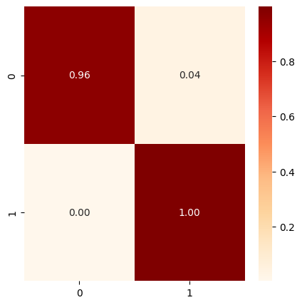

```
Random Forest with Bagging Classifier:
              precision    recall  f1-score   support

           0       1.00      0.99      0.99    527751
           1       0.99      1.00      0.99    527539

    accuracy                           0.99   1055290
   macro avg       0.99      0.99      0.99   1055290
weighted avg       0.99      0.99      0.99   1055290
```

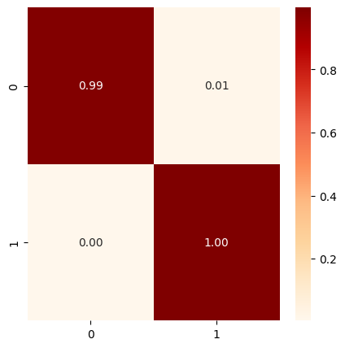

```
Modelo de ML basado en predicciones ponderadas de los 3 modelos anteriores:
              precision    recall  f1-score   support

           0       0.95      0.99      0.97    527751
           1       0.99      0.94      0.97    527539

    accuracy                           0.97   1055290
   macro avg       0.97      0.97      0.97   1055290
weighted avg       0.97      0.97      0.97   1055290
```

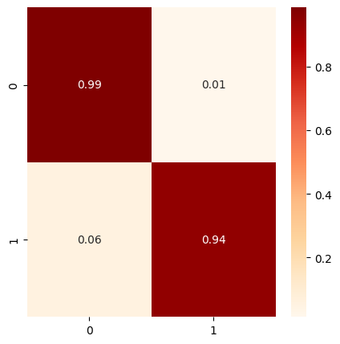

```
VotingClassifier:
              precision    recall  f1-score   support

           0       1.00      0.99      0.99    527751
           1       0.99      1.00      0.99    527539

    accuracy                           0.99   1055290
   macro avg       0.99      0.99      0.99   1055290
weighted avg       0.99      0.99      0.99   1055290
```

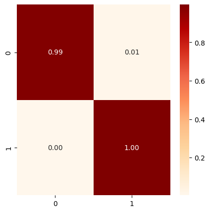

```python
with open("data_clean2.pickle", "rb") as archivo:
    data = pickle.load(archivo)

target="fraud"
data=smote_sample(data,target)
X_train , X_test , y_train , y_test, y_one_hot_train, y_one_hot_test=escaled_min_max(data,target)
# X_train , X_test , y_train , y_test, y_one_hot_train, y_one_hot_test=without_escaled(data,target)

# Random Forest Classifier
print("Random Forest Classifier:")
model_rf = RandomForestClassifier(random_state=20).fit(X_train, y_train)
y_pred_rf = model_rf.predict(X_test)
performance_measure(y_test, y_pred_rf)

print("Random Forest Classifier class_weight:")
model_rf = RandomForestClassifier(random_state=20,class_weight="balanced").fit(X_train, y_train)
y_pred_rf = model_rf.predict(X_test)
performance_measure(y_test, y_pred_rf)

print("Linear SVC:")
model_rf = LinearSVC(random_state=0, tol=1e-5,class_weight="balanced").fit(X_train, y_train)
y_pred_rf = model_rf.predict(X_test)
performance_measure(y_test, y_pred_rf)

# BalancedRandomForestClassifier
print("Balanced Random Forest Classifier:")
model_brf = BalancedRandomForestClassifier(n_estimators=100, random_state=0).fit(X_train, y_train)
y_pred_brf = model_brf.predict(X_test)
performance_measure(y_test, y_pred_brf)

# Easy Ensemble Classifier
print("Easy Ensemble Classifier:")
model_eec = EasyEnsembleClassifier(n_estimators=5, random_state=0).fit(X_train, y_train)
y_pred_eec = model_eec.predict(X_test)
performance_measure(y_test, y_pred_eec)

# Random Forest with Bagging Classifier
print("Random Forest with Bagging Classifier:")
model_rfbc = BalancedBaggingClassifier(estimator=RandomForestClassifier(),
                                       sampling_strategy='auto',
                                       replacement=False,
                                       random_state=0).fit(X_train, y_train)
y_pred_rfbc = model_rfbc.predict(X_test)
performance_measure(y_test, y_pred_rfbc)

# Modelo de ML basado en predicciones ponderadas de los 3 modelos anteriores
print("Modelo de ML basado en predicciones ponderadas de los 3 modelos anteriores:")
y_pred = y_pred_rf * 0.5 + y_pred_brf * 0.2 + y_pred_eec * 0.3
y_pred = (y_pred > 0.5).astype(int)
performance_measure(y_test, y_pred)

# VotingClassifier
print("VotingClassifier:")
vote_est = [
    ('brf', BalancedRandomForestClassifier(random_state=0)),
    ('bbc', BalancedBaggingClassifier(estimator=RandomForestClassifier(), random_state=0)),
    ('eec', EasyEnsembleClassifier(random_state=0))
]

model_vc = VotingClassifier(estimators=vote_est, voting='soft').fit(X_train, y_train)
y_pred_vc = model_vc.predict(X_test).astype(int)
performance_measure(y_test, y_pred_vc)
```

```python
dict_parameter={}
#  Random Forest
parameters = {
    'n_estimators' : [50],
    'criterion' : ['gini'],
    'max_features' : ['sqrt'],
    'n_jobs':[-1]
}
dict_parameter["Ramdon Forest"]=(RandomForestClassifier(random_state=20),parameters)

#Random Forest Classifier class_weight:
parameters = {
    'n_estimators' : [50],
    'criterion' : ['gini'],
    'max_features' : ['sqrt'],
    'n_jobs':[-1]
}
dict_parameter["Ramdon Forest pond"]=(RandomForestClassifier(random_state=20,class_weight="balanced"),parameters)

# Linear SVC ponderado:
parameters = {}
dict_parameter["Linear SVC pond"]=(LinearSVC(random_state=0, tol=1e-5,class_weight="balanced"),parameters)

# BalancedRandomForestClassifier
parameters = {
    'n_estimators' : [50],
    'criterion' : ['gini'],
    'max_features' : ['sqrt'],
    'n_jobs':[-1]
    }
dict_parameter["Balanced Random ForestClassifier"]=(BalancedRandomForestClassifier(random_state=20),parameters)


# EasyEnsembleClassifier
parameters = {'n_estimators' : [1]}
dict_parameter["Easy Ensemble Classifier"]=(EasyEnsembleClassifier(random_state=20),parameters)


# BalancedBaggingClassifier
parameters = {'n_estimators' : [5] }
dict_parameter["Balanced Bagging Classifier"]=(BalancedBaggingClassifier(random_state=20),parameters)
dict_parameter.keys()
```

```
dict_keys(['Ramdon Forest', 'Ramdon Forest pond', 'Linear SVC pond', 'Balanced Random ForestClassifier', 'Easy Ensemble Classifier', 'Balanced Bagging Classifier'])
```

```python
def grid_model_parameter(dict_model,X_train , X_test , y_train , y_test,dict_parameter,fold_cv,sample_key):
    l_model_key=list(dict_parameter.keys())
    Dict_sample_model={}
    for i in range(len(l_model_key)):
        model_key=l_model_key[i]
        print("sample_key:",sample_key,"Modelo:",model_key)
        Model,parameters=dict_parameter[model_key]

        model_grid=GridSearchCV(estimator=Model, cv=fold_cv, param_grid=parameters).fit(X_train , y_train)
        best_model=model_grid.best_estimator_
        Dict_sample_model[model_key]=best_model

        #y_pred_test=best_model.predict(X_test)
        #performance_measure(y_test,y_pred_test)
    Dict_sample_model["Sample"]=X_train , X_test , y_train , y_test
    dict_model[sample_key]=Dict_sample_model
    return dict_model
```

# Busqueda de modelo de ML adecuada usando grid

## Calcular mejor Modelo de ML para cada grid

```python
fold_cv = 5

dict_grid_model={}
with open("data_clean2.1.pickle", "rb") as archivo:
    data = pickle.load(archivo)

target="fraud"
X_train , X_test , y_train , y_test, y_one_hot_train, y_one_hot_test=escaled_min_max(data,target)
dict_grid_model["SinTecnicasMuestreo"]=X_train , X_test , y_train , y_test

target="fraud"
data1=under_sampling(data,target)
X_train , X_test , y_train , y_test, y_one_hot_train, y_one_hot_test=escaled_min_max(data1,target)
dict_grid_model["UnderSampling"]=X_train , X_test , y_train , y_test

target="fraud"
data=over_sampling(data,target)
X_train , X_test , y_train , y_test, y_one_hot_train, y_one_hot_test=escaled_min_max(data,target)
dict_grid_model["MCR_Oversampling"]=X_train , X_test , y_train , y_test     # muestreo con repeticion

target="fraud"
data=smote_sample(data,target)
X_train , X_test , y_train , y_test, y_one_hot_train, y_one_hot_test=escaled_min_max(data,target)
dict_grid_model["Smote"]=X_train , X_test , y_train , y_test

tipo_sample = dict_grid_model.keys()
dict_grid_model_updated = dict_grid_model.copy()

for sample_key in tipo_sample:
    # Desempaquetar los datos de entrenamiento y prueba
    X_train, X_test, y_train, y_test = dict_grid_model[sample_key]
    # Actualizar el diccionario con los resultados del modelo
    dict_grid_model_updated = grid_model_parameter(
        dict_grid_model_updated, X_train, X_test, y_train, y_test, dict_parameter, fold_cv, sample_key
    )

# Guarda los resultados actualizados en un archivo pickle
with open("Grid_model.pickle", "wb") as archivo:
    pickle.dump(dict_grid_model_updated, archivo)
```

```
Num fraude: 7193
Num No fraude: 586272
Num fraude: 7193
Num No fraude: 586272
sample_key: SinTecnicasMuestreo Modelo: Ramdon Forest
sample_key: SinTecnicasMuestreo Modelo: Ramdon Forest pond
sample_key: SinTecnicasMuestreo Modelo: Linear SVC pond
sample_key: SinTecnicasMuestreo Modelo: Balanced Random ForestClassifier
sample_key: SinTecnicasMuestreo Modelo: Easy Ensemble Classifier
sample_key: SinTecnicasMuestreo Modelo: Balanced Bagging Classifier
sample_key: UnderSampling Modelo: Ramdon Forest
sample_key: UnderSampling Modelo: Ramdon Forest pond
sample_key: UnderSampling Modelo: Linear SVC pond
sample_key: UnderSampling Modelo: Balanced Random ForestClassifier
sample_key: UnderSampling Modelo: Easy Ensemble Classifier
sample_key: UnderSampling Modelo: Balanced Bagging Classifier
sample_key: MCR_Oversampling Modelo: Ramdon Forest
sample_key: MCR_Oversampling Modelo: Ramdon Forest pond
sample_key: MCR_Oversampling Modelo: Linear SVC pond
sample_key: MCR_Oversampling Modelo: Balanced Random ForestClassifier
sample_key: MCR_Oversampling Modelo: Easy Ensemble Classifier
sample_key: MCR_Oversampling Modelo: Balanced Bagging Classifier
sample_key: Smote Modelo: Ramdon Forest
sample_key: Smote Modelo: Ramdon Forest pond
sample_key: Smote Modelo: Linear SVC pond
sample_key: Smote Modelo: Balanced Random ForestClassifier
sample_key: Smote Modelo: Easy Ensemble Classifier
sample_key: Smote Modelo: Balanced Bagging Classifier
```

## Calcular medidas de los modelos del grid

```python
with open("Grid_model.pickle", "rb") as archivo:
    dict_grid_model = pickle.load(archivo)

labels=["No fraude","Fraude"]
column_names = ["tipo sample",'Model_ML',"train_precision_0","train_recall_0","train_f1_0","train_precision_1","train_recall_1","train_f1_1",
                                         "test_precision_0","test_recall_0","test_f1_0","test_precision_1","test_recall_1","test_f1_1","roc_auc","pr_auc"]
df = pd.DataFrame(columns=column_names)

l_tipo_sample=list(dict_grid_model.keys())
#i=0
for i in range(len(l_tipo_sample)):
    tipo_sample=l_tipo_sample[i]

    dict_sample=dict_grid_model[tipo_sample]
    X_train , X_test , Y_train , Y_test=dict_sample["Sample"]
    l_grid_models=list(set(dict_sample.keys()) -{"Sample"})

    for ii in range(len(l_grid_models)):
        #ii=0
        new_row=[]
        name_grid_model=l_grid_models[ii]
        grid_model=dict_sample[name_grid_model]
        new_row.extend([tipo_sample,name_grid_model])

        # Medidas de datos train
        y_pred_train=grid_model.predict(X_train)
        dict_medidas = classification_report(Y_train, y_pred_train,target_names=labels,output_dict=True)

        for clase in labels:  # Usar dict_medidas.keys() directamente
            precision = dict_medidas[clase]["precision"]
            recall = dict_medidas[clase]["recall"]
            f1 = dict_medidas[clase]['f1-score']
            support = dict_medidas[clase]["support"]

            new_row.extend([precision, recall, f1])  # Añadir las métricas a new_row
        # Medidas de datos test
        y_pred_test=grid_model.predict(X_test)
        #dict_medidas=classification_report(Y_test, y_pred_test,output_dict=True)
        dict_medidas=classification_report(Y_test, y_pred_test,target_names=labels,output_dict=True)
        for clase in labels:
            precision=dict_medidas[clase]["precision"]
            recall=dict_medidas[clase]["recall"]
            f1=dict_medidas[clase]['f1-score']
            support=dict_medidas[clase]["support"]

            new_row.extend([precision,recall,f1])

        fpr, tpr, thresholds_roc = roc_curve(Y_test, y_pred_test)
        roc_auc = roc_auc_score(Y_test, y_pred_test)
        new_row.append(roc_auc)

        precision, recall, thresholds_pr = precision_recall_curve(Y_test, y_pred_test)
        pr_auc = auc(recall, precision)
        new_row.append(pr_auc)

        # Agrego la fila del modelo para el caso especifico
        df.loc[len(df)] = new_row

# Guarda los resultados actualizados en un archivo pickle
with open("Grid_model_medidas.pickle", "wb") as archivo:
    pickle.dump(df, archivo)
```

```python
with open("Grid_model_medidas.pickle", "rb") as archivo:
    df_medidas = pickle.load(archivo)


col=['tipo sample','Model_ML',"test_precision_1",'test_recall_1','test_f1_1', 'roc_auc','pr_auc']
df_medidas[col].sort_values(by='test_precision_1', ascending=False).head(5)
```

|  | tipo sample | Model_ML | test_precision_1 | test_recall_1 | test_f1_1 | roc_auc | pr_auc |
| --- | --- | --- | --- | --- | --- | --- | --- |
| 12 | MCR_Oversampling | Ramdon Forest pond | 0.987475 | 1.0 | 0.993698 | 0.993655 | 0.993737 |
| 18 | Smote | Ramdon Forest pond | 0.987475 | 1.0 | 0.993698 | 0.993655 | 0.993737 |
| 13 | MCR_Oversampling | Ramdon Forest | 0.987456 | 1.0 | 0.993689 | 0.993646 | 0.993728 |
| 19 | Smote | Ramdon Forest | 0.987456 | 1.0 | 0.993689 | 0.993646 | 0.993728 |
| 22 | Smote | Balanced Random ForestClassifier | 0.987366 | 1.0 | 0.993643 | 0.993600 | 0.993683 |

```python
col=['tipo sample','Model_ML',"test_precision_0",'test_recall_0','test_f1_0', 'roc_auc','pr_auc']
df_medidas[col].sort_values(by='test_precision_0', ascending=False).head(5)
```

|  | tipo sample | Model_ML | test_precision_0 | test_recall_0 | test_f1_0 | roc_auc | pr_auc |
| --- | --- | --- | --- | --- | --- | --- | --- |
| 12 | MCR_Oversampling | Ramdon Forest pond | 1.0 | 0.987311 | 0.993615 | 0.993655 | 0.993737 |
| 13 | MCR_Oversampling | Ramdon Forest | 1.0 | 0.987292 | 0.993605 | 0.993646 | 0.993728 |
| 22 | Smote | Balanced Random ForestClassifier | 1.0 | 0.987199 | 0.993558 | 0.993600 | 0.993683 |
| 19 | Smote | Ramdon Forest | 1.0 | 0.987292 | 0.993605 | 0.993646 | 0.993728 |
| 18 | Smote | Ramdon Forest pond | 1.0 | 0.987311 | 0.993615 | 0.993655 | 0.993737 |

# Medidas

```python
with open("Grid_model_medidas.pickle", "rb") as archivo:
    df_medidas = pickle.load(archivo)

col1='tipo sample'
dom=list(df_medidas[col1].unique())
rec=["STM", "US", "MCR", "SMOTE"]
df_medidas[col1+"_2"] = df_medidas[col1].replace(dom,rec)
#print(df_medidas[col+"_2"])

col="Model_ML"
dom=list(df_medidas[col].unique())
rec=["RF Pond", "RF", "EEC", "SVC Pond","BRF","BBC"]
df_medidas[col+"_2"] = df_medidas[col].replace(dom,rec)
#print(df_medidas[col+"_2"])

df_medidas['Sample&Model'] = df_medidas[col1+"_2"] +" "+ df_medidas[col+"_2"]
#df_medidas['Sample&Model']
```

```python
columnas=["Sample&Model","test_precision_1",'test_recall_1','test_f1_1', 'roc_auc','pr_auc']
df_medidas[columnas]
```

|  | Sample&Model | test_precision_1 | test_recall_1 | test_f1_1 | roc_auc | pr_auc |
| --- | --- | --- | --- | --- | --- | --- |
| 0 | STM RF Pond | 0.872207 | 0.728521 | 0.793915 | 0.863605 | 0.802011 |
| 1 | STM RF | 0.855573 | 0.756594 | 0.803045 | 0.877512 | 0.807561 |
| 2 | STM EEC | 0.242215 | 0.983804 | 0.388725 | 0.972993 | 0.613108 |
| 3 | STM SVC Pond | 0.389680 | 0.941231 | 0.551170 | 0.961559 | 0.665812 |
| 4 | STM BRF | 0.253107 | 0.989511 | 0.403104 | 0.976817 | 0.621373 |
| 5 | STM BBC | 0.289653 | 0.978868 | 0.447027 | 0.974686 | 0.634388 |
| 6 | US RF Pond | 0.968916 | 0.983228 | 0.976020 | 0.975720 | 0.980281 |
| 7 | US RF | 0.969927 | 0.982613 | 0.976229 | 0.975955 | 0.980634 |
| 8 | US EEC | 0.968423 | 0.981536 | 0.974935 | 0.974641 | 0.979613 |
| 9 | US SVC Pond | 0.986421 | 0.883059 | 0.931883 | 0.935404 | 0.964088 |
| 10 | US BRF | 0.968684 | 0.985228 | 0.976886 | 0.976565 | 0.980663 |
| 11 | US BBC | 0.968631 | 0.978766 | 0.973672 | 0.973412 | 0.979028 |
| 12 | MCR RF Pond | 0.987475 | 1.000000 | 0.993698 | 0.993655 | 0.993737 |
| 13 | MCR RF | 0.987456 | 1.000000 | 0.993689 | 0.993646 | 0.993728 |
| 14 | MCR EEC | 0.970122 | 0.985387 | 0.977695 | 0.977514 | 0.981409 |
| 15 | MCR SVC Pond | 0.982342 | 0.941541 | 0.961509 | 0.962305 | 0.976559 |
| 16 | MCR BRF | 0.987366 | 1.000000 | 0.993643 | 0.993600 | 0.993683 |
| 17 | MCR BBC | 0.987089 | 1.000000 | 0.993502 | 0.993457 | 0.993544 |
| 18 | SMOTE RF Pond | 0.987475 | 1.000000 | 0.993698 | 0.993655 | 0.993737 |
| 19 | SMOTE RF | 0.987456 | 1.000000 | 0.993689 | 0.993646 | 0.993728 |
| 20 | SMOTE EEC | 0.970122 | 0.985387 | 0.977695 | 0.977514 | 0.981409 |
| 21 | SMOTE SVC Pond | 0.982342 | 0.941541 | 0.961509 | 0.962305 | 0.976559 |
| 22 | SMOTE BRF | 0.987366 | 1.000000 | 0.993643 | 0.993600 | 0.993683 |
| 23 | SMOTE BBC | 0.987089 | 1.000000 | 0.993502 | 0.993457 | 0.993544 |

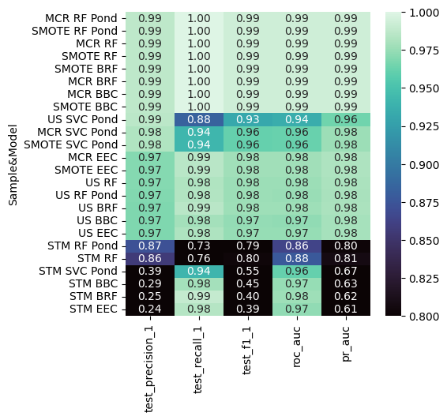

```python
with open("Grid_model_medidas.pickle", "rb") as archivo:
    df_medidas = pickle.load(archivo)


col1='tipo sample'
dom=list(df_medidas[col1].unique())
rec=["STM", "US", "MCR", "SMOTE"]
df_medidas[col1+"_2"] = df_medidas[col1].replace(dom,rec)
#print(df_medidas[col+"_2"])

col="Model_ML"
dom=list(df_medidas[col].unique())
rec=["RF Pond", "RF", "EEC", "SVC Pond","BRF","BBC"]
df_medidas[col+"_2"] = df_medidas[col].replace(dom,rec)
#print(df_medidas[col+"_2"])

df_medidas['Sample&Model'] = df_medidas[col1+"_2"] +" "+ df_medidas[col+"_2"]
#df_medidas['Sample&Model']

df=df_medidas[columnas]
fig = plt.figure()
df.set_index('Sample&Model', inplace=True)
df1=df.sort_values(by='test_precision_1', ascending=False)
sns.heatmap(df1, cmap='mako',fmt=".2f",annot = True, vmin=0.8, vmax=1)
plt.show()
```

# Conclusiones:

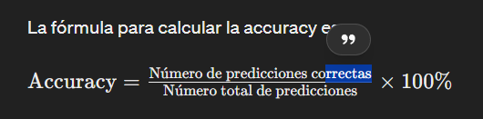

Entenderlo como que tomas uns subset de la muestra con solamente item de una clase, entonces todas las predicciones deberian ser de esa clase.

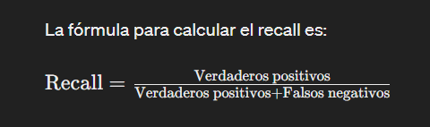

Este es más díficil de entender, tomamos un subset de la muestra, esto arroajará predicciones tanto negativas como positivas. Ahora tomamos todas las prediciones que fueron positivas, y hacemos la razón. Es decir esta medida se centra en ver la calidad de la predicción de cierta clase.

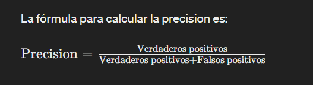

F1:

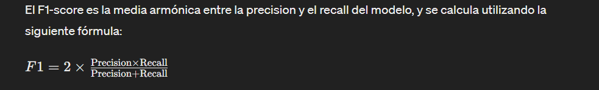

Es una medida que tiende a mantener el equilibrio entre las medidas recall y precisión

Objetivo:  
Mi objetivo en este trabajo es minizar la cantidad de fraudes, por lo tanto mi modelo de ML cuando tenga en frente un dato de tipo fraude, este debería predecir correctamente que es fraude. Dado lo anterior debemos maximizar el valor de recall, ya que a mayor valor de recall se minimizan los falsos negativos de una clase, y si consideramos a la clase "fraude" entonces se minimizan los casos de Falsos negativos de la clase "No fraude". En otras palabras, se miniza el caso en que se tiene un dato de tipo fraude y se predice como no fraude.

## Razonamiento de resolución del problema:

Se puede ver en el mapa de calor que tenemos varios modelos potenciales a pesar que de que se entrenaron con sólo el $10\%$ de los datos.

[figure not shown]

Esto quiero decir que existen varios modelos que pueden reconocer bien un dato tipo fraude cuando se les entrega. Por otro lado, como tenemos varios métodos con recall bueno, entonces también podremos centrarnos en el valor de la precisión. Se puede ver en la imagen que del grupo de los métodos con buen recall, los métodos con buena precisión son radom forest con pesos ponderados, random forest utilizando métodos de muestreos de tipo oversampling, ya sea SMOTE o a través de una muestra con repetición de la clase minoritaria. Por definición de presición de un modelo de ML se tiene que estos modelos cuando predigan que es "fraude" se tendrá una alta probabilidad de que sea "fraude".

En resumen los mejores modelos son el random forest ponderado y random forest utilizando oversamplig, ya sea SMOTE o a través de una muestra con repetición de la clase minoritaria.

## Observaciones importantes:

Razonamiento 2. Condición: Si el modelo tiende a predecir siempre negativo. Ahora considerando el recall de la clase mayoritaria "No fraude" y que las muestras de "No fraude" son mucho más grandes que la de "Fraude", entonces el valor del recall de la clase mayoritaria siempre será muy alto. Esto es debido a que el subconjunto de la muestra de la clase mayoritaria es mucho mayor que la clase minoritaria y si el modelo tiende a predecir siempre negativo, entonces los verdaderos negativos (en este caso) serán muchos más que los falsos positivos.